# Joining and clipping

This tutorial builds on the previous section on plotting and highlights some of R's more advanced spatial functions. We look at joining new datasets to our data - an attribute join - spatial joins, whereby data is added to the target layer depending on the location of the origins and clipping.

## Joining based on attributes

To reaffirm our starting point, let's re-plot the only spatial dataset in our workspace, and count the number of polygons:

```r
library(rgdal)
lnd <- readOGR(dsn = ".", "london_sport")
```

```
## with 33 features and 4 fields
## Feature type: wkbPolygon with 2 dimensions
```

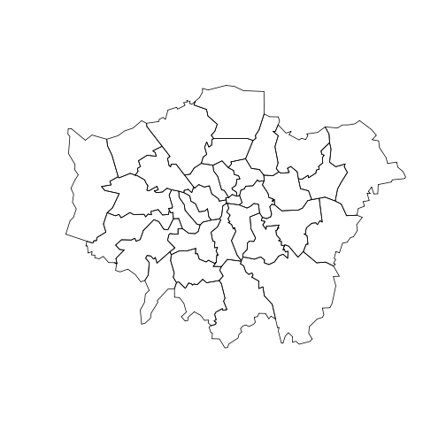

```r
plot(lnd)
```

```r
nrow(lnd)
```

```
## [1] 33
```

### Downloading additional data

Because we are using borough-level data, and boroughs are official administrative zones, there is much data available at this level. We will use the example of crime data to illustrate this data availability, and join this with the current spatial dataset. As before, we can download and import the data from within R:

```r
# download.file('http://data.london.gov.uk/datafiles/crime-community-safety/mps-recordedcrime-borough.csv',
# destfile = 'mps-recordedcrime-borough.csv') uncomment the above line of
# code to download the data

crimeDat <- read.csv("mps-recordedcrime-borough.csv")  # flags an error
```

Initially, the `read.csv` command flags an error: open the raw .csv file in a text editor such as Notepad, Notepad++ or GVIM, find the problem and correct it. Alternatively, you can work out what the file encoding is and use the correct argument (this is not recommended - simpler just to edit the text file in most cases).

```r
crimeDat <- read.csv("mps-recordedcrime-borough.csv", fileEncoding = "UCS-2LE")
head(crimeDat)
```

```
##    Month                   MajorText                   MinorText
## 1 201104 Violence Against The Person              Common Assault
## 2 201104                    Burglary      Burglary In A Dwelling
## 3 201104   Other Notifiable Offences            Other Notifiable
## 4 201104                     Robbery           Personal Property
## 5 201104            Theft & Handling       Handling Stolen Goods
## 6 201104            Theft & Handling Theft/Taking Of Pedal Cycle
##   CrimeCount   Spatial_DistrictName
## 1         81 Kensington and Chelsea
## 2         78 Kensington and Chelsea
## 3         12 Kensington and Chelsea
## 4         41 Kensington and Chelsea
## 5          3 Kensington and Chelsea
## 6         59 Kensington and Chelsea
```

```r
summary(crimeDat$MajorText)
```

```
##                    Burglary             Criminal Damage
##                        1543                        3125
##                       Drugs             Fraud & Forgery
##                        1925                        1581
##   Other Notifiable Offences                     Robbery
##                        1374                        1517
##             Sexual Offences            Theft & Handling
##                        1557                        6264
## Violence Against The Person
##                        4885
```

```r
crimeTheft <- crimeDat[which(crimeDat$MajorText == "Theft & Handling"), ]
head(crimeTheft)
```

```
##     Month        MajorText                              MinorText
## 5  201104 Theft & Handling                  Handling Stolen Goods
## 6  201104 Theft & Handling            Theft/Taking Of Pedal Cycle
## 13 201104 Theft & Handling Motor Vehicle Interference & Tampering
## 15 201104 Theft & Handling               Theft From Motor Vehicle
## 21 201104 Theft & Handling                           Theft Person
## 23 201104 Theft & Handling          Theft/Taking Of Motor Vehicle
##    CrimeCount   Spatial_DistrictName
## 5           3 Kensington and Chelsea
## 6          59 Kensington and Chelsea
## 13          5 Kensington and Chelsea
## 15        132 Kensington and Chelsea
## 21         76 Kensington and Chelsea
## 23         45 Kensington and Chelsea
```

```r
crimeAg <- aggregate(CrimeCount ~ Spatial_DistrictName, FUN = "sum", data = crimeTheft)
head(crimeAg)  # show the aggregated crime data
```

```
##   Spatial_DistrictName CrimeCount
## 1 Barking and Dagenham      12222
## 2               Barnet      19821
## 3               Bexley       8155
## 4                Brent      16823
## 5              Bromley      15172
## 6               Camden      36493
```

Now that we have crime data at the borough level, the challenge is to join it by name. This is not always straightforward. Let us see which names in the crime data match the spatial data:

```r
lnd$name %in% crimeAg$Spatial_DistrictName
```

```
##  [1]  TRUE  TRUE  TRUE  TRUE  TRUE  TRUE  TRUE  TRUE  TRUE  TRUE  TRUE
## [12]  TRUE  TRUE  TRUE  TRUE  TRUE  TRUE  TRUE  TRUE  TRUE  TRUE  TRUE
## [23]  TRUE  TRUE  TRUE  TRUE  TRUE  TRUE  TRUE  TRUE  TRUE  TRUE FALSE
```

```r
lnd$name[which(!lnd$name %in% crimeAg$Spatial_DistrictName)]
```

```
## [1] City of London
## 33 Levels: Barking and Dagenham Barnet Bexley Brent Bromley ... Westminster
```

The first line of code above shows that all but one of the borough names matches; the second tells us that it is City of London that is named differently in the crime data:

```r
levels(crimeAg$Spatial_DistrictName)
```

```
##  [1] "Barking and Dagenham"   "Barnet"
##  [3] "Bexley"                 "Brent"
##  [5] "Bromley"                "Camden"
##  [7] "Croydon"                "Ealing"
##  [9] "Enfield"                "Greenwich"
## [11] "Hackney"                "Hammersmith and Fulham"
## [13] "Haringey"               "Harrow"
## [15] "Havering"               "Hillingdon"
## [17] "Hounslow"               "Islington"
## [19] "Kensington and Chelsea" "Kingston upon Thames"
## [21] "Lambeth"                "Lewisham"
## [23] "Merton"                 "Newham"
## [25] "NULL"                   "Redbridge"
## [27] "Richmond upon Thames"   "Southwark"
## [29] "Sutton"                 "Tower Hamlets"
## [31] "Waltham Forest"         "Wandsworth"
## [33] "Westminster"
```

```r
levels(crimeAg$Spatial_DistrictName)[25] <- as.character(lnd$name[which(!lnd$name %in%
    crimeAg$Spatial_DistrictName)])
lnd$name %in% crimeAg$Spatial_DistrictName  # now all columns match
```

```
##  [1] TRUE TRUE TRUE TRUE TRUE TRUE TRUE TRUE TRUE TRUE TRUE TRUE TRUE TRUE
## [15] TRUE TRUE TRUE TRUE TRUE TRUE TRUE TRUE TRUE TRUE TRUE TRUE TRUE TRUE
## [29] TRUE TRUE TRUE TRUE TRUE
```

The above code block first identified the row with the faulty name and then renamed the level to match the `lnd` dataset. Note that we could not rename the variable directly, as it is stored as a factor.

We are now ready to join the datasets. It is recommended to use the `join` function in the `plyr` package but the `merge` function could equally be used.

```r
`?`(join)
library(plyr)
`?`(join)
```

The documentation for join will be displayed if the plyr package is loaded (if not, load or install and load it!). It requires all joining variables to have the same name, so we will rename the variable to make the join work:

```r
head(lnd$name)
```

```
## [1] Bromley              Richmond upon Thames Hillingdon
## [4] Havering             Kingston upon Thames Sutton
## 33 Levels: Barking and Dagenham Barnet Bexley Brent Bromley ... Westminster
```

```r
head(crimeAg$Spatial_DistrictName)  # the variables to join
```

```
## [1] Barking and Dagenham Barnet               Bexley
## [4] Brent                Bromley              Camden
## 33 Levels: Barking and Dagenham Barnet Bexley Brent Bromley ... Westminster
```

```r
crimeAg <- rename(crimeAg, replace = c(Spatial_DistrictName = "name"))
head(join(lnd@data, crimeAg))  # test it works
```

```
##   ons_label                 name Partic_Per Pop_2001 CrimeCount
## 1      00AF              Bromley       21.7   295535      15172
## 2      00BD Richmond upon Thames       26.6   172330       9715
## 3      00AS           Hillingdon       21.5   243006      15302
## 4      00AR             Havering       17.9   224262      12611
## 5      00AX Kingston upon Thames       24.4   147271       9023
## 6      00BF               Sutton       19.3   179767       8810
```

```r
lnd@data <- join(lnd@data, crimeAg)
```

## Adding point data for clipping and spatial join

In addition to joing by zone name, it is also possible to do [spatial joins](http://help.arcgis.com/en/arcgisdesktop/10.0/help/index.html#//00080000000q000000) in R. There are three main varieties: many-to-one - where the values of many intersecting objects contribute to a new variable in the main table - one-to-many, or one-to-one. Because boroughs in London are quite large, we will conduct a many-to-one spatial join. We will be using Tube Stations as the spatial data to join, with the aim of finding out which and how many stations are found in each London borough.

```r
download.file("http://www.personal.leeds.ac.uk/~georl/egs/lnd-stns.zip", "lnd-stns.zip")
unzip("lnd-stns.zip")
library(rgdal)
stations <- readOGR(dsn = ".", layer = "lnd-stns", p4s = "+init=epsg:27700")
```

```
## with 2532 features and 27 fields
## Feature type: wkbPoint with 2 dimensions
```

```r
proj4string(stations)  # this is the full geographical detail.
```

```
## [1] "+init=epsg:27700 +proj=tmerc +lat_0=49 +lon_0=-2 +k=0.9996012717 +x_0=400000 +y_0=-100000 +datum=OSGB36 +units=m +no_defs +ellps=airy +towgs84=446.448,-125.157,542.060,0.1502,0.2470,0.8421,-20.4894"
```

```r
proj4string(lnd)
```

```
## [1] "+proj=tmerc +lat_0=49 +lon_0=-2 +k=0.9996012717 +x_0=400000 +y_0=-100000 +ellps=airy +units=m +no_defs"
```

```r
bbox(stations)
```

```
##              min    max
## coords.x1 455435 602523
## coords.x2 122266 227704
```

```r
bbox(lnd)
```

```
##      min    max
## x 503571 561941
## y 155851 200932
```

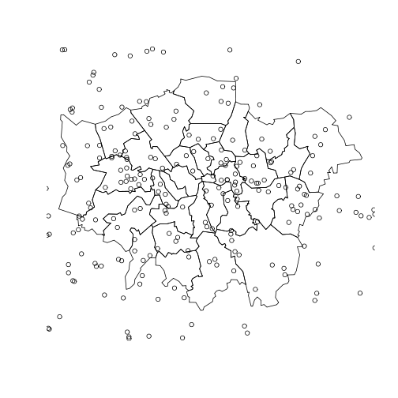

```r
stationsWGS <- spTransform(stations, CRSobj = CRS(proj4string(lnd)))
stations <- stationsWGS
rm(stationsWGS)
plot(lnd)
points(stations[sample(1:nrow(stations), size = 500), ])
```

## Clipping

There are a number of functions that we can use to clip the points so that only those falling within London boroughs are retained:

```r
`?`(overlay)
`?`(sp::over)
library(rgeos)
`?`(rgeos::gIntersects)
```

We can write off the first one straight away as it is depreciated by the second. It seems that `gIntersects` can produce the same output as `over`, based on [discussion](http://gis.stackexchange.com/questions/63793/how-to-overlay-a-polygon-over-spatialpointsdataframe-and-preserving-the-spdf-dat) in the community, so either can be used. (See this [discussion](http://stackoverflow.com/questions/15881455/how-to-clip-worldmap-with-polygon-in-r) for further alternatives.) In this tutorial we will use `gIntersects`, for clipping although we could equally use `gContains`, `gWithin` and other `g...` functions - see rgeos help pages by typing `?gOverlaps` or other functions for more. `gIntersects` will output information for each point, telling us which polygon it interacts with (i.e. the polygon it is in):

```r
int <- gIntersects(stations, lnd, byid = T)  # find which stations intersect
class(int)  # it's outputed a matrix
```

```
## [1] "matrix"
```

```r
dim(int)  # with 33 rows (one for each zone) and 2532 cols (the points)
```

```
## [1]   33 2532
```

```r
summary(int[, c(200, 500)])  # not the output of this
```

```
##     200             500
##  Mode :logical   Mode :logical
##  FALSE:33        FALSE:32
##  NA's :0         TRUE :1
##                  NA's :0
```

```r
plot(lnd)
points(stations[200, ], col = "red")  # note point id 200 is outside the zones
points(stations[500, ], col = "green")  # note point 500 is inside
which(int[, 500] == T)  # this tells us that point 500 intersects with zone 32
```

```
## 31
## 32
```

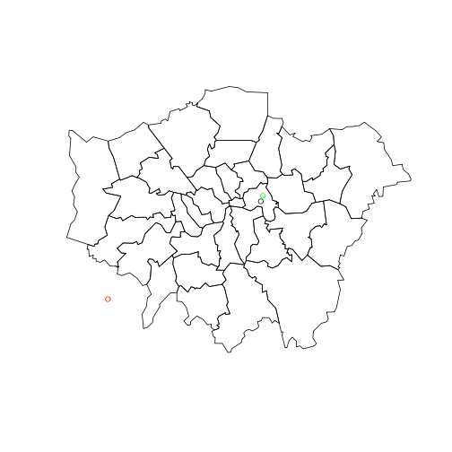

```r
points(coordinates(lnd[32, ]), col = "black")  # test the previous statement
```

In the above code, only the first line actually 'does' anything in our workspace, by creating the object `int`. The proceeding lines are dedicated to exploring this object and what it means. Note that it is a matrix with columns corresponding to the points and rows corresponding to boroughs. The borough in which a particular point can be extracted from `int` as we shall see below. For the purposes of clipping, we are only interested in whether the point intersects with *any* of the boroughs. This is where the function `apply`, which is unique to R, comes into play:

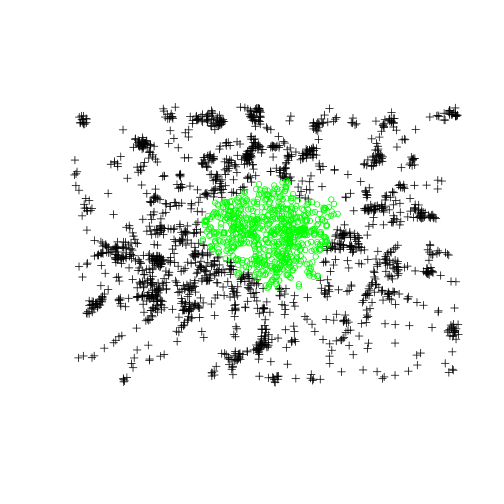

```r
clipped <- apply(int == F, MARGIN = 2, all)
plot(stations[which(clipped), ])  # shows all stations we DO NOT want
stations.cl <- stations[which(!clipped), ]  # use ! to select the invers
points(stations.cl, col = "green")  # check that it's worked
```

```r
stations <- stations.cl
rm(stations.cl)  # tidy up: we're only interested in clipped ones
```

The first line instructs R to look at each column (`MARGIN = 2`, we would use `MARGIN = 1` for row-by-row analysis) and report back whether `all` of the values are false. This creates the inverse selection that we want, hence the use of `!` to invert it. We test that the function works on a new object (often a good idea, to avoid overwriting useful data) with plots and, once content that the clip has worked, save the sample of points to our main `stations` object and remove the now duplicated `stations.cl` object.

## Aggregating the data to complete the spatial join

Now that we know how `gIntersects` works in general terms and for clipping, let's use it to allocate a borrough to each of our station points, which we will then aggregate up. Data from these points (e.g. counts, averages in each area etc.) can then be transferred to the main polygons table: the essence of a spatial join. Again, `apply` is our friend in this instance, meaning we can avoid `for` loops:

```r
int <- gIntersects(stations, lnd, byid = T)  # re-run the intersection query
head(apply(int, MARGIN = 2, FUN = which))
```

```
## 91 92 93 94 95 96
##  6 10 10 10 10 10
```

```r
b.indexes <- which(int, arr.ind = T)
summary(b.indexes)
```

```
##       row          col
##  Min.   : 1   Min.   :  1
##  1st Qu.: 7   1st Qu.:183
##  Median :15   Median :366
##  Mean   :15   Mean   :366
##  3rd Qu.:22   3rd Qu.:548
##  Max.   :33   Max.   :730
```

```r
b.names <- lnd$name[b.indexes[, 1]]
b.count <- aggregate(b.indexes ~ b.names, FUN = length)
head(b.count)
```

```
##                b.names row col
## 1 Barking and Dagenham  12  12
## 2               Barnet  29  29
## 3               Bexley  28  28
## 4                Brent  30  30
## 5              Bromley  54  54
## 6               Camden  14  14
```

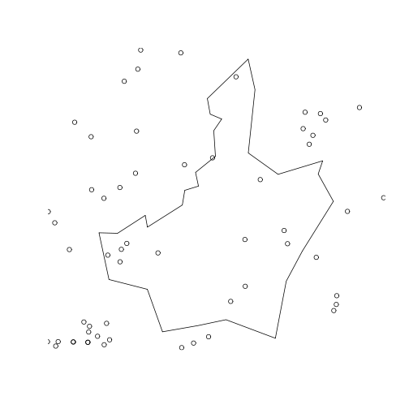

```r
plot(lnd[which(grepl("Barking", lnd$name)), ])
points(stations)
```

Now the fun part: count the points in the polygon and report back how many there are!

```r
b.count <- rename(b.count, replace = c(b.names = "name"))
b.count.tmp <- join(lnd@data, b.count)
head(b.count.tmp)
```

```
##   ons_label                 name Partic_Per Pop_2001 CrimeCount row col
## 1      00AF              Bromley       21.7   295535      15172  54  54
## 2      00BD Richmond upon Thames       26.6   172330       9715  22  22
## 3      00AS           Hillingdon       21.5   243006      15302  43  43
## 4      00AR             Havering       17.9   224262      12611  18  18
## 5      00AX Kingston upon Thames       24.4   147271       9023  12  12
## 6      00BF               Sutton       19.3   179767       8810  12  12
```

```r
lnd$station.count <- b.count.tmp[, 7]
```

We have now seen how to join and clip data. Next, for a stronger grounding in how ggplot works, we will look at plotting non-spatial data.